# 08.Example 2

Modified

Tu 2023-10-03 11:55

## Given:

Water flows at a velocity $u_\infty = 1\ \frac{\mathrm{m}}{\mathrm{s}}$ over a flat plate of length $L = 0.6\ \mathrm{m}$. Consider two cases, one for which the water temperature is approximately $300\ \mathrm{K}$ and the other for an approximate water temperature of $350\ \mathrm{K}$. In the laminar and turbulent regions, experimental measurements show that the local convection coefficients are well described by

$$h_{lam}(x) = C_{lam}x^{-0.5}$$

$$h_{tur}(x) = C_{tur}x^{-0.2}$$

where $x$ has units of $m$. At $300\ \mathrm{K}$,

$$C_{lam,300\ \mathrm{K}}= 395\ \frac{\mathrm{W}}{\left(\mathrm{K} \cdot \mathrm{m}^{1.5}\right)}$$

$$C_{tur,300\ \mathrm{K}} = 2330\ \frac{\mathrm{W}}{\left(\mathrm{K} \cdot \mathrm{m}^{1.8}\right)}$$

while at $350\ \mathrm{K}$,

$$C_{lam,350\ \mathrm{K}} = 477\ \frac{\mathrm{W}}{\left(\mathrm{K} \cdot \mathrm{m}^{1.5}\right)}$$

$$C_{tur,350\ \mathrm{K}} = 3600\ \frac{\mathrm{W}}{\left(\mathrm{K} \cdot \mathrm{m}^{1.8}\right)}$$

As is evident, the constant $C$ depends on the nature of the flow as well as the water temperature because of the thermal dependence of various properties of the fluid.

## Required:

Determine the average convection coefficient, $\bar{h}$, over the entire plate for the two water temperatures. Plot the convective coefficients as a function of $x$ for the entire length of the flat plate. On the plot, show the average convective coefficient values.

## Solution:

Start first by importing any needed libraries.

```python
import matplotlib.pyplot as plt
import numpy as np
```

The given functions for the convective coefficients may be defined as Python functions to aid in calculating the values and when plotting. This is shown below.

```python
def h_lamFunc(C, x):
    return C*x**-0.5

def h_turFunc(C, x):
    return C*x**-0.2
```

The density $\rho$ and dynamic viscosity $\mu$ of water needs to be used and may be found in Table A.6. Table A.6 does not have density values but it does have specific volume. From Table A.6, the specific volume $\nu$ and dynamic viscosity $\mu$ at $300\ \mathrm{K}$ and $350\ \mathrm{K}$ are defined below.

$$\nu_{f,300\ \mathrm{K}} = 0.001003\ \frac{\mathrm{m}^{3}}{\mathrm{kg}}$$

$$\mu_{300\ \mathrm{K}} = 0.000855\ \frac{\mathrm{N} \cdot \mathrm{s}}{\mathrm{m}^{2}}$$

$$\nu_{f,350\ \mathrm{K}} = 0.001027\ \frac{\mathrm{m}^{3}}{\mathrm{kg}}$$

$$\mu_{350\ \mathrm{K}} = 0.000365\ \frac{\mathrm{N} \cdot \mathrm{s}}{\mathrm{m}^{2}}$$

The density values may then be found by taking the inverse of the specific volume. This is shown below.

$$\rho_{300\ \mathrm{K}} = \frac{1}{v_{f300K}} = 997.0\ \frac{\mathrm{kg}}{\mathrm{m}^{3}}$$

$$\rho_{350\ \mathrm{K}} = \frac{1}{v_{f350K}} = 973.7\ \frac{\mathrm{kg}}{\mathrm{m}^{3}}$$

The critical Reynolds number (which is $5.0 \times 10^5$ for flow over a flat plate) may be used to determine the critical location $x_c$. The definition of the Reynolds number is shown below.

$$Re_{x}=\frac{\rho u_\infty x}{\mu}$$

Solving for the critical location, the Reynolds number definition becomes

$$x_c=\frac{Re_{x,c}\mu}{\rho u_\infty}$$

The critical locations for the two temperatures is then

$$x_{c,300\ \mathrm{K}} = \frac{Re_{xc} \mu_{300K}}{\rho_{300K} u_\infty} = 0.429\ \mathrm{m}$$

$$x_{c,350\ \mathrm{K}} = \frac{Re_{xc} \mu_{350K}}{\rho_{350K} u_\infty} = 0.187\ \mathrm{m}$$

The average convective coefficient $\bar{h}$ value is given by

$$\bar{h}=\frac{1}{L} \int_0^L h\left(x\right) dx$$

However, the local convective coefficient $h$ is not a single function for the length of $L$. The integral must be broken into two parts to account for the laminar and turbulent portion. This is shown below.

$$\bar{h}=\frac{1}{L}\left( \int_0^{x_c} h_{lam}\left(x\right) dx + \int_{x_c}^L h_{tur}\left(x\right) dx\right)$$

These two integrals may now be evaluated for each of their limits. This is shown below.

Answer: $\bar{h}_{300\ \mathrm{K}} = \frac{1}{L}[ \frac{C_{lam300K}}{0.5}x_{c300K}^{0.5} + \frac{C_{tur300K}}{0.8} (L^{0.8} - x_{c300K}^{0.8} )] = 1.622\ \frac{\mathrm{kW}}{\left(\mathrm{K} \cdot \mathrm{m}^{2}\right)}$

Answer: $\bar{h}_{350\ \mathrm{K}} = \frac{1}{L}[ \frac{C_{lam350K}}{0.5}x_{c350K}^{0.5} + \frac{C_{tur350K}}{0.8} (L^{0.8} - x_{c350K}^{0.8} )] = 3.708\ \frac{\mathrm{kW}}{\left(\mathrm{K} \cdot \mathrm{m}^{2}\right)}$

The plotting values for $x$ and the $h$ terms will be created using [Numpy’s](https://docs.scipy.org/doc/numpy/index.html) linspace. This is shown below.

```python
x_lam300 = np.linspace(0.01, x_c300, 100)
x_tur300 = np.linspace(x_c300, L, 100)
x_300 = np.concatenate([x_lam300, x_tur300])

x_lam350 = np.linspace(0.01, x_c350, 100)
x_tur350 = np.linspace(x_c350, L, 100)
x_350 = np.concatenate([x_lam350, x_tur350])

h_lam300 = h_lamFunc(C_lam300, x_lam300)
h_tur300 = h_turFunc(C_tur300, x_tur300)
h_300 = np.concatenate([h_lam300, h_tur300])

h_lam350 = h_lamFunc(C_lam350, x_lam350)
h_tur350 = h_turFunc(C_tur350, x_tur350)
h_350 = np.concatenate([h_lam350, h_tur350])
```

The plotting handle may now be created and plotting elements added to the plot. This is shown below.

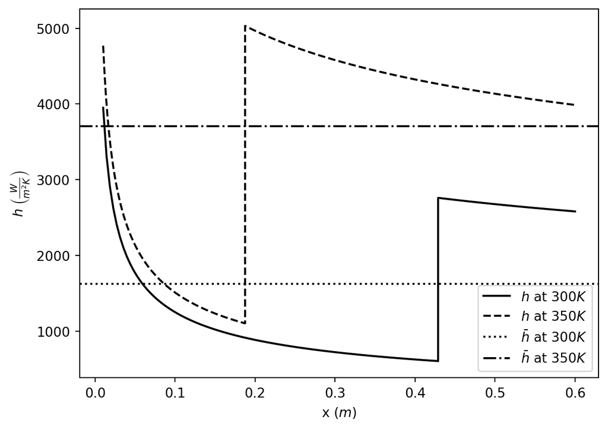

```python
fig, ax=plt.subplots(1, 1)

ax.plot(x_300, h_300, color = 'k', label = '$h$ at $300 K$')
ax.plot(x_350, h_350, color = 'k', linestyle = 'dashed', label = '$h$ at $350 K$')

ax.set_xlabel('x $\\left(m\\right)$')
ax.set_ylabel('$h\\ \\left( \\frac{W}{m^2 K}\\right)$')

ax.axhline(hb_300, color = 'k', linestyle = 'dotted', label = '$\\bar{h}$ at $300 K$')
ax.axhline(hb_350, color = 'k', linestyle = 'dashdot', label = '$\\bar{h}$ at $350 K$')

ax.legend()

plt.show()
```